# **An Analysis of United States Religious Congregations**

**Spring 2025 Data Science Project**

**Alex Blackert, Penelope Cook, Vinay Kavuri, and Anisha Narasimhan**

1. Contributions
2. Introduction
3. Data Curation & Preprocessing
4. Exploratory Data Analysis

```
a. Analyzing for Outliers

b. Chi-Squared Hypothesis Test -  *Does region impact Hindu denomination?*

c. ANOVA Hypothesis Test - *Does year impact the proportion of the population that is an adherent to a religious group?*
```

5. Primary Analysis - *What features best predict a high adherence rate?*
6. Visualization
7. Conclusion

# **1. Contributions**

Vinay Kavuri: Worked on Hypothesis Tests in part 4, as well as the visualization of the results of the primary analysis in part 6.

Alex Blackert: Completed the outlier analysis in part 4, as well as ML implementation and testing. Edited hypothesis test 2.

Penelope Cook: Came up with the project idea, performed all data set curation and preprocessing. Also edited both code and text in the primary analysis section for consistency.

Anisha Narasimhan: Wrote the conclusion section, as well as explanatory text in several sections. Edited hypothesis test code.

# **2. Introduction**

Religious Congregations serve as social and cultural pillars in the United States, offering community, support, and guidance to their adherents. This analysis aims to identify some factors that influence congregation size, and understand how these factors can vary based on geography, and over time.

Specifically, questions we seek to answer are: What features best predict a high adherence rate in a U.S. county? How does region affect religious affiliation patterns, particularly within Hindu demoninations?

Our primary analysis aims to look at features that best predict a high adherence rate.

Understanding these relationships helps better understand the role of these religious congregations on the general population, and can inform both general sociological discussions and policy decisions regarding these demographics.

# **3. Data Curation & Preprocessing**

The data used in this project (Long_relig.csv) was sourced from a public dataset on religious congregations across the United States (from the Association of Religious Data Archives [ARDA]). It includes data from 1980 to 2010 like the number of congregations, adherents, religious families, as well as geographic data such as county and state.

Source: https://www.thearda.com/data-archive?fid=RCMSMGCY&tab=3

## **Preprocessing**

```python
#Set up
import pandas as pd
Long_relig = pd.read_csv('Long_relig.csv')
```

```python
Long_relig.info()
```

```
<class 'pandas.core.frame.DataFrame'>
RangeIndex: 276629 entries, 0 to 276628
Data columns (total 14 columns):
 #   Column    Non-Null Count   Dtype
---  ------    --------------   -----
 0   FIPSMERG  276629 non-null  int64
 1   CNTYNM    276629 non-null  object
 2   STATEAB   276629 non-null  object
 3   YEAR      276629 non-null  int64
 4   TOTPOP    276629 non-null  int64
 5   GRPCODE   276629 non-null  object
 6   GRPNAME   276629 non-null  object
 7   ADHERENT  261449 non-null  float64
 8   CONGREG   275139 non-null  float64
 9   RELTRAD   276629 non-null  int64
 10  FAMILY    272943 non-null  float64
 11  NOTE_MIS  276629 non-null  int64
 12  NOTE_COM  276629 non-null  int64
 13  NOTE_MEA  276629 non-null  int64
dtypes: float64(3), int64(7), object(4)
memory usage: 29.5+ MB
```

```python
Long_relig
```

|  | FIPSMERG | CNTYNM | STATEAB | YEAR | TOTPOP | GRPCODE | GRPNAME | ADHERENT | CONGREG | RELTRAD | FAMILY | NOTE_MIS | NOTE_COM | NOTE_MEA |
| --- | --- | --- | --- | --- | --- | --- | --- | --- | --- | --- | --- | --- | --- | --- |
| 0 | 1001 | Autauga County | AL | 1980 | 32259 | 005 | African Methodist Episcopal Zion Church | 1914.0 | 7.0 | 6 | 92.0 | 0 | 0 | 1 |
| 1 | 1001 | Autauga County | AL | 1980 | 32259 | 017 | American Baptist Association | 95.0 | 1.0 | 1 | 96.0 | 4 | 0 | 0 |
| 2 | 1001 | Autauga County | AL | 1980 | 32259 | 053 | Assemblies of God | 110.0 | 1.0 | 1 | 94.0 | 0 | 0 | 0 |
| 3 | 1001 | Autauga County | AL | 1980 | 32259 | 081 | Catholic Church | 43.0 | 1.0 | 3 | 87.0 | 0 | 0 | 2 |
| 4 | 1001 | Autauga County | AL | 1980 | 32259 | 089 | The Christian and Missionary Alliance | 204.0 | 1.0 | 1 | 93.0 | 0 | 0 | 0 |
| ... | ... | ... | ... | ... | ... | ... | ... | ... | ... | ... | ... | ... | ... | ... |
| 276624 | 56045 | Weston County | WY | 2010 | 7208 | 413 | Seventh-day Adventists | 54.0 | 2.0 | 1 | 98.0 | 0 | 0 | 0 |
| 276625 | 56045 | Weston County | WY | 2010 | 7208 | 419 | Southern Baptist Convention | 48.0 | 1.0 | 1 | 96.0 | 0 | 0 | 3 |
| 276626 | 56045 | Weston County | WY | 2010 | 7208 | 449 | The United Methodist Church, old count | 421.0 | 2.0 | 2 | 92.0 | 0 | 0 | 0 |
| 276627 | 56045 | Weston County | WY | 2010 | 7208 | 449N | The United Methodist Church, new count | 482.0 | 2.0 | 2 | 92.0 | 0 | 0 | 0 |
| 276628 | 56045 | Weston County | WY | 2010 | 7208 | 500 | Non-denominational | 188.0 | 1.0 | 1 | NaN | 0 | 0 | 1 |

276629 rows × 14 columns

### **Checking for NA Values**

```python
Long_relig.isna().sum()
```

```
FIPSMERG        0
CNTYNM          0
STATEAB         0
YEAR            0
TOTPOP          0
GRPCODE         0
GRPNAME         0
ADHERENT    15180
CONGREG      1490
RELTRAD         0
FAMILY       3686
NOTE_MIS        0
NOTE_COM        0
NOTE_MEA        0
dtype: int64
```

### **Cleaning family column**

```python
Long_relig_cl1 = Long_relig.copy() #A copy to change
Long_relig_cl1[Long_relig_cl1['FAMILY'].isna()]['GRPNAME'].unique()
# array(['Non-denominational', 'Independent Non-Charismatic Churches', # both considered other groups https://www.thearda.com/us-religion/group-profiles/groups?D=586 https://www.thearda.com/us-religion/group-profiles/groups?D=422
#        'International Fellowship of Bible Churches', #This will be put with the Holiness family because of this source: https://www.thearda.com/us-religion/group-profiles/groups?D=431
#        'International Fellowship of Christian Assemblies'], dtype=object) #Put as Pentacostal https://www.thearda.com/us-religion/group-profiles/groups?D=432
```

```
array(['Non-denominational', 'Independent Non-Charismatic Churches',
       'International Fellowship of Bible Churches',
       'International Fellowship of Christian Assemblies'], dtype=object)
```

ARDA considers both Non-denominational and Independent Non-Charismatic Churches to be in the other groups family category - https://www.thearda.com/us-religion/group-profiles/groups?D=586 https://www.thearda.com/us-religion/group-profiles/groups?D=422.

The other missing family values with use the site as well.

International Fellowship of Bible Churches will be put with the Holiness family - https://www.thearda.com/us-religion/group-profiles/groups?D=431.

International Fellowship of Christian Assemblies will be put as Pentacostal - https://www.thearda.com/us-religion/group-profiles/groups?D=432.

```python
Long_relig_cl1.loc[(Long_relig_cl1['GRPNAME']=='Non-denominational') | (Long_relig_cl1['GRPNAME']=='Independent Non-Charismatic Churches'),'FAMILY'] = 113
Long_relig_cl1.loc[Long_relig_cl1['GRPNAME']=='International Fellowship of Bible Churches','FAMILY'] = 93
Long_relig_cl1.loc[Long_relig_cl1['GRPNAME']=='International Fellowship of Christian Assemblies','FAMILY'] = 94
Long_relig_cl1.isna().sum()
```

```
FIPSMERG        0
CNTYNM          0
STATEAB         0
YEAR            0
TOTPOP          0
GRPCODE         0
GRPNAME         0
ADHERENT    15180
CONGREG      1490
RELTRAD         0
FAMILY          0
NOTE_MIS        0
NOTE_COM        0
NOTE_MEA        0
dtype: int64
```

### **Cleaning the Adherent Column**

```python
#Which religious groups do not show the number of adherents they have?
NA_adherents = Long_relig_cl1[Long_relig_cl1['ADHERENT'].isna()]['GRPNAME'].value_counts(dropna = False).reset_index()
NA_adherents_not = Long_relig_cl1[Long_relig_cl1['ADHERENT'].notna()]['GRPNAME'].value_counts().reset_index()
NA_adherents_not = NA_adherents_not.rename(columns = {'count':'NOT_NA_COUNT'})
adherent_clean = NA_adherents.merge(NA_adherents_not, how= 'left')
adherent_clean
```

|  | GRPNAME | count | NOT_NA_COUNT |
| --- | --- | --- | --- |
| 0 | Jehovah's Witnesses | 2200 | NaN |
| 1 | United Pentecostal Church International | 1671 | NaN |
| 2 | Church of Christ Scientist | 1592 | NaN |
| 3 | Calvary Chapel Fellowship Churches | 954 | NaN |
| 4 | Independent Fundamental Churches of America | 728 | 6.0 |
| ... | ... | ... | ... |
| 82 | Covenant Reformed Presbyterian Church | 3 | NaN |
| 83 | Conservative Lutheran Association | 3 | NaN |
| 84 | American Presbyterian Church | 3 | NaN |
| 85 | Albanian Orthodox Diocese of America | 2 | 4.0 |
| 86 | Free Reformed Church of North America | 2 | NaN |

87 rows × 3 columns

Out of the groups that have at least one location that has a missing ADHERENT value, 63 out of the 87 religious groups have all their locations missing an ADHERENT value. This indicates that the missing ADHERENT data for the 63 groups is MNAR (Missing Not At Random), as every location in that religious group did not disclose their adherent size. Since this could point to a broader trend of specific religious groups not disclosing their adherent counts, this could be the case for specific locations within other groups. Since the majority of the missing adherent values are all missing across several groups, these points will be removed when performing analysis involving on the adherent column. However, we do not want to remove them before any analysis, as the presence of the groups may be important in future analysis that does not involve an adherent count.

### Missing Congregation Values

```python
NA_congreg = Long_relig_cl1[Long_relig_cl1['CONGREG'].isna()]['GRPNAME'].value_counts(dropna = False)
NA_congreg
```

```
GRPNAME
Black Baptists Estimate    1490
Name: count, dtype: int64
```

Since all of the missing congregation values belong to a single group and the group is an estimate rather than a survey of particular congregations, there is no congregation data to be gathered.

# **4. Exploratory Data Analysis**

## **Analyzing for outliers**

We can start out exploratory analysis by checking for outliers in the numerical columns of our data. We would like to find any points that are numerical outliers, then determine whether or not they fit within the context of the data and how we should handle them. Ideally, a Z-score would be calculated for the numerical columns of the data points to check for outliers. First, the numerical columns need to be checked to see if they are normal. We can make some plots of the data to visually check for normality.

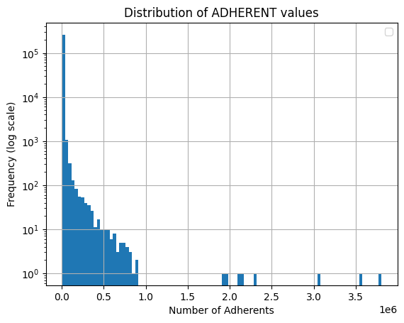

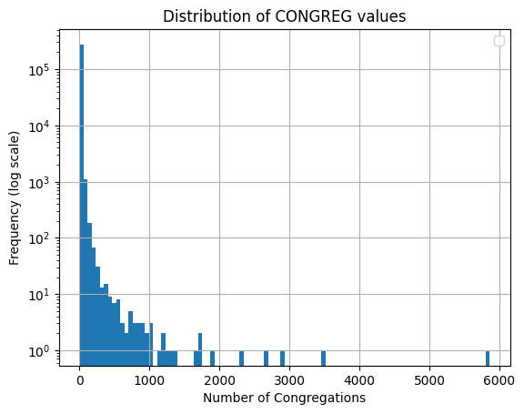

```python
import matplotlib.pyplot as plt
import numpy as np

#Check for normality

#adherent plot
plt.figure()
Long_relig_cl1['ADHERENT'].hist(bins = 100)
plt.yscale('log')
plt.title('Distribution of ADHERENT values')
plt.xlabel('Number of Adherents')
plt.ylabel('Frequency (log scale)')
plt.legend()
plt.show()

#congreg plot
plt.figure()
Long_relig_cl1['CONGREG'].hist(bins = 100)
plt.yscale('log')
plt.title('Distribution of CONGREG values')
plt.xlabel('Number of Congregations')
plt.ylabel('Frequency (log scale)')
plt.legend()
plt.show()
```

Here we can see that both columns are dramatically dominated by low values near 0. Obviously there can be no negative values, so we naturally see a large right skew on the data. Since this data is so heavily skewed right, we can take a logarithm to check if it is log-normal, or at least use log to visually check for outliers. Lines indicating the mean and 4 standard deviations away from the column mean are shown to help inspect for outliers.

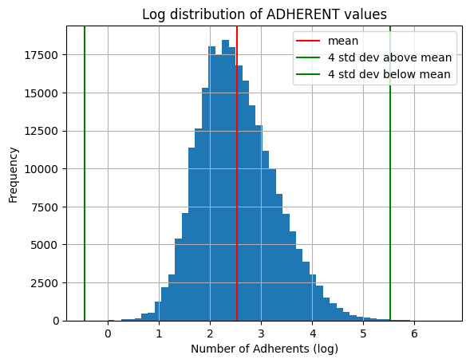

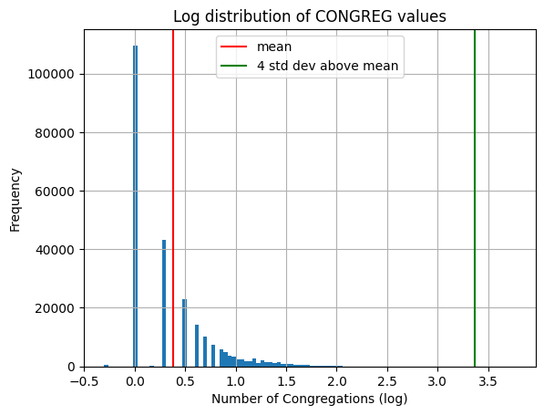

```python
#Check for log-normal

#taking log, need to remove 0s
test_frame = Long_relig_cl1.copy()
test_frame = test_frame[(test_frame['ADHERENT'] > 0) & (test_frame['ADHERENT'].notna())]
test_frame = test_frame[(test_frame['CONGREG'] > 0) & (test_frame['CONGREG'].notna())]
test_frame['log_adherent'] = np.log10(test_frame['ADHERENT'])
test_frame['log_congreg'] = np.log10(Long_relig_cl1['CONGREG'])
#log mean/std
adherent_mean = test_frame['log_adherent'].mean()
adherent_std = test_frame['log_adherent'].std()
congreg_mean = test_frame['log_congreg'].mean()
congreg_std = test_frame['log_congreg'].std()
#Adherent log plot
plt.plot()
test_frame['log_adherent'].hist(bins = 50)
plt.axvline(adherent_mean, color = 'red', label = 'mean')
plt.axvline((adherent_mean + adherent_std*4), color = 'green', label = '4 std dev above mean')
plt.axvline((adherent_mean - adherent_std*4), color = 'green', label = '4 std dev below mean')
plt.title('Log distribution of ADHERENT values')
plt.xlabel('Number of Adherents (log)')
plt.ylabel('Frequency')
plt.legend()
plt.show()
#Congreg log plot
plt.plot()
test_frame['log_congreg'].hist(bins = 100)
plt.axvline(congreg_mean, color = 'red', label = 'mean')
plt.axvline((congreg_mean + adherent_std*4), color = 'green', label = '4 std dev above mean')
plt.title('Log distribution of CONGREG values')
plt.xlabel('Number of Congregations (log)')
plt.ylabel('Frequency')
plt.legend()
plt.show()
```

**Adherent** Here we see that the ADHERENT column appears close to log-normal, se we can calculate a Z-score for each point to find the points more than 4 standard deviaitons away from the mean.

**Congreg** The congreg column is not log-normal, so we can try to examine the points for the original plot that are notably far from the rest of the data.

```python
adherent_outliers = test_frame[abs((test_frame['log_adherent'] - adherent_mean) / adherent_std) > 4]
#congreg_outliers = test_frame[abs((test_frame['log_congreg'] - congreg_mean) / congreg_std) > 4]
congreg_outliers = Long_relig_cl1[Long_relig_cl1['CONGREG'] > 1000]
print(f'Number of potential outliers in ADHERENT: {len(adherent_outliers)}')
print(f'Number of potential outliers in CONGREG: {len(congreg_outliers)}')
```

```
Number of potential outliers in ADHERENT: 133
Number of potential outliers in CONGREG: 18
```

99.99% of a distribution should be contained within 4 standard deviations of the mean. With a data set of roughly 250,000 points, we would expect near 25 points outside 4 standard deviations, but we find 133. This indicates that some of the leading points visible in the initial standard graph might indeed be outliers, even accounting for a log-normal distribution. We should now check what religious groups have values so high and decide whether to remove them.

```python
print('Groups with points marked as potential outliers for the ADHERENT column:' , adherent_outliers['GRPNAME'].unique())
print('Groups with points marked as potential outliers for the CONGREG column:' , congreg_outliers['GRPNAME'].unique())
```

```
Groups with points marked as potential outliers for the ADHERENT column: ['Catholic Church'
 'Jewish Estimate (both conservatives, reformed, and orthodox)'
 'Non-denominational' 'Southern Baptist Convention'
 'The Church of Jesus Christ of Latter-day Saints']
Groups with points marked as potential outliers for the CONGREG column: ['Moravian Church in America, Alaska and North Province Combined'
 'Friends Groups Combined'
 'The Church of Jesus Christ of Latter-day Saints']
```

Of the five groups present in the set of potential outliers, 'Jewish Estimate' and 'Non-denominational' are both aggregting several communities. 'Catholic Church', 'Southern Baptist Churst', and 'The Church of Jesus Christ of Latter-day Saints' all have a large presence in America, so adherent numbers significantly higher than other religious groups could be expected. Because these groups making up the located potential outliers fit within the context of the data, we should not remove them. Instead their potential impact should be taken into account when performing all future analysis, where decisions can be made more accurately to the specfic need of the analysis being performed.

There are only 3 groups marked as potential outliers for the CONGREG column. 'The Church of Jesus Christ of Latter-day Saints' appears as a potential outlier for adherents as well, and will be dealt with in the same way. The other two groups are combinations of groups or areas, so it is natural that there would be a large number of congregations. Additionally, the largest point with near 6000 congregations represents combined rural areas, so an exceptionally large number of congregations is to be expected. Again, these points will be left in the data set since they make sense in context, but they may be ignored in future analysis, due to their numerical impacts, or due to them being merged groups rather than singular groups.

## **Hypothesis Test: Does region impact Hindu denomination?**

We would first like to explore how some of the categorical variables in our data may influence each other. A specific example we can use is how geographical region (splitting states into NorthEast, South, MidWest, West), may impact Hindu denomination.

HO: In 2010, the region a Hindu adherent resides in does not have an effect on the likelihood of the religious group they affiliate with.

HA: In 2010, the region a Hindu adherent resides in does have an effect on the likelihood of the religious group they affiliate with.

In this hypothesis test, we are comparing two categorical variables. The first is the region, which we can derive from the [US Census' division of states into regions](https://www2.census.gov/geo/pdfs/maps-data/maps/reference/us_regdiv.pdf). The second is the religious groups affiliated with the religion of Hinduism, which we can find by looking for religious groups with "Hindu" in the name.

Let's filter our dataset to only consider the relevant rows, as well as add a column with the associated region:

```python
state_to_region = {
    'CT': 'Northeast', 'ME': 'Northeast', 'MA': 'Northeast', 'NH': 'Northeast',
    'RI': 'Northeast', 'VT': 'Northeast', 'NJ': 'Northeast', 'NY': 'Northeast', 'PA': 'Northeast',

    'IL': 'Midwest', 'IN': 'Midwest', 'MI': 'Midwest', 'OH': 'Midwest', 'WI': 'Midwest',
    'IA': 'Midwest', 'KS': 'Midwest', 'MN': 'Midwest', 'MO': 'Midwest', 'NE': 'Midwest', 'ND': 'Midwest', 'SD': 'Midwest',

    'DE': 'South', 'FL': 'South', 'GA': 'South', 'MD': 'South', 'NC': 'South', 'SC': 'South',
    'VA': 'South', 'DC': 'South', 'WV': 'South', 'AL': 'South', 'KY': 'South', 'MS': 'South',
    'TN': 'South', 'AR': 'South', 'LA': 'South', 'OK': 'South', 'TX': 'South',

    'AZ': 'West', 'CO': 'West', 'ID': 'West', 'MT': 'West', 'NV': 'West', 'NM': 'West',
    'UT': 'West', 'WY': 'West', 'AK': 'West', 'CA': 'West', 'HI': 'West', 'OR': 'West', 'WA': 'West'
}

Long_relig_cl1["REGION"] = Long_relig_cl1["STATEAB"].map(state_to_region)
hindu_2010 = Long_relig_cl1[(Long_relig_cl1["GRPNAME"].str.contains(r'hindu', case=False, regex=True)) & (Long_relig_cl1["YEAR"] == 2010)]
```

Since we are comparing two different categorical variables, a chi-squared test would be appropriate to conduct.

First we must create a contingency table with the columns and rows representing one of the categorical variables and adding together the total number of adherents where those two variables overlap.

```python
contingency_table = pd.pivot_table(
    hindu_2010,
    values='ADHERENT',
    index='REGION',
    columns='GRPNAME',
    aggfunc='sum',
    fill_value=0
)
contingency_table
```

| GRPNAME REGION | Hindu Post Renaissance | Hindu Renaissance | Indian-American Hindu Temple Associations | Traditional Hindu Temples |
| --- | --- | --- | --- | --- |
| Midwest | 4220.0 | 914.0 | 40365.0 | 44004.0 |
| Northeast | 13325.0 | 1524.0 | 85328.0 | 62254.0 |
| South | 7770.0 | 2671.0 | 108833.0 | 90570.0 |
| West | 11405.0 | 19093.0 | 69624.0 | 79286.0 |

Here we have created the contingency table with four different Hindu religious groups representing the columns, and the four geographical US regions representing the rows.

Before we conduct our chi-squared test, it may be helpful to visualize our data in the contingency table with a graphical interpretation. We can create a stacked bar chart so that we can compare the proportions for each Hindu religious group per region.

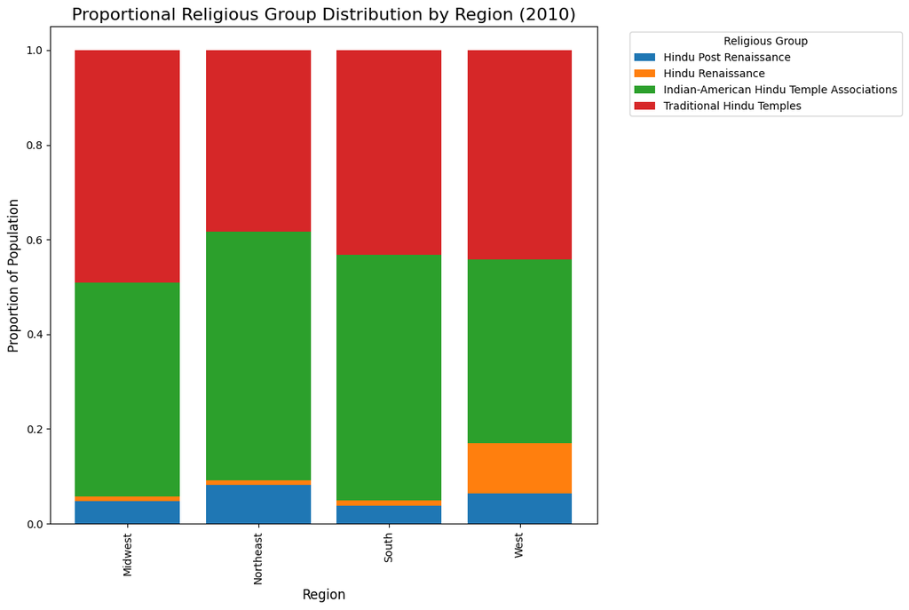

```python
fig, ax = plt.subplots(figsize=(12, 8))

normalized_table = contingency_table.div(contingency_table.sum(axis=1), axis=0)

bottom = None
for group in normalized_table.columns:
    ax.bar(
        normalized_table.index,
        normalized_table[group],
        label=group,
        bottom=bottom
    )
    if bottom is None:
        bottom = normalized_table[group]
    else:
        bottom += normalized_table[group]

ax.set_title("Proportional Religious Group Distribution by Region (2010)", fontsize=16)
ax.set_xlabel("Region", fontsize=12)
ax.set_ylabel("Proportion of Population", fontsize=12)
plt.xticks(rotation=90)
ax.legend(title="Religious Group", bbox_to_anchor=(1.05, 1), loc='upper left')
plt.tight_layout()
plt.show()
```

In the stacked bar chart, we can make a few observations. While the proportions may seem similar at first glance, there are definetely some differences worth looking at. We can see that in the Western United States, a Hindu adherent is way more likely to be a part of the Hindu renaissance than in any other US region. Similarly, in the Midwestern United States, a Hindu adherent is way more likely to be a part of the Traditional Hindu Temples than any other US region.

Finally, let's put our contingency table into the chi-squared statistical test to see whether we can reject our null hypothesis:

```python
import scipy.stats as stats

result = stats.chi2_contingency(contingency_table)
result.pvalue
```

```
0.0
```

After running the chi-squared test, we received a p value of near 0. This p value is much smaller than our $\alpha = 0.05$, so we can definitively reject our null hypothesis. Therefore, we can conclude our alternate hypothesis must be true and that the region a Hindu adherent resides in has an effect on the likelihood of the religious group they affiliate with.

## **Hypothesis Test: Does year impact the proportion of the population that is an adherent to a religious group?**

HO: The year does not have an effect on the proportion of adherents to the total population for a religious group

HA: The year does have an effect on the proportion of adherents to the total population for a religious group

Since we want to use an ANOVA test, which assumes a normal distribution, we should check that first. We will take the aggregate adherent value for each group as a proportion of the population of the counties they are in. Then, since the adherent column is log normal, we will take a log of this to check for normality.

```python
agg_group = test_frame[test_frame["ADHERENT"].notna() & (test_frame["TOTPOP"] != 0)].groupby(["GRPNAME", "YEAR"], as_index=False).agg({
    "ADHERENT": "sum",
    "TOTPOP": "sum"
})
agg_group["PROP_ADHER"] = np.log10(agg_group["ADHERENT"] / agg_group["TOTPOP"])
data_1980 = agg_group[agg_group["YEAR"] == 1980]
data_1990 = agg_group[agg_group["YEAR"] == 1990]
data_2000 = agg_group[agg_group["YEAR"] == 2000]
data_2010 = agg_group[agg_group["YEAR"] == 2010]
```

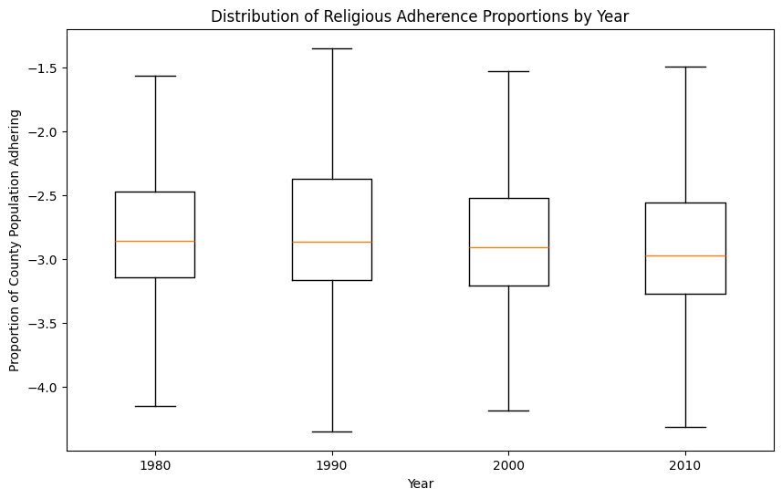

```python
plt.figure(figsize=(10, 6))
plt.boxplot(
    [data_1980["PROP_ADHER"], data_1990["PROP_ADHER"], data_2000["PROP_ADHER"], data_2010["PROP_ADHER"]],
    labels=["1980", "1990", "2000", "2010"],
    showfliers=False
)

plt.title("Distribution of Religious Adherence Proportions by Year")
plt.xlabel("Year")
plt.ylabel("Proportion of County Population Adhering")
plt.show()
```

The boxplots above show a roughly normal ditribution. Now we can perform our ANOVA test.

```python
result = stats.f_oneway(data_1980["PROP_ADHER"], data_1990["PROP_ADHER"], data_2000["PROP_ADHER"], data_2010["PROP_ADHER"])
result.pvalue
```

```
0.1707691836343849
```

After running the ANOVA hypothesis test, the p-value is 0.17. Since this is greater than our significance level $\alpha = 0.05$, we fail to reject the null hypothesis. This indicates that there is no statistically significant evidence to suggest that the year has an effect on the proportion of adherents to the total population of a religious group.

# **5. Primary Analysis**

## **What features best predict a high adherence rate?**

**Goal:** Train classifiers on the data set and then, given they test well, look at feature importances to see which features of our data are the best predictors of high adherance rate. There are several features in out data that may strongly predict high adherence rates, all reviewed below.

**Features we will use in X (input features):**

Congreg: Number of congregations the group has. It is likely this will be the dominant feature, since in general it is intuitive to think a group with several congregations would have larger adherence numbers. However, we found searching for outliers that there are several groups with very high numbers of congregations but lower adherence rates (rural areas). There also may be large groups in heavily populated areas with few congregations but very high adherence numbers.

State: Encoded state abbreviaiton. It is also intuitive that certain states would be more relgious in general than others (The Bible Belt for example), so State would have some influence over number of adherents. **Note: Adherence rate is taken as a proportion of population, as to not overweight states with high populations (which would naturally result in high adherence values).**

FAMILY: Religious family category. Some relgious sects are larger than others, so once again it is intuitive that this would be a predictor of adherent numbers.

REL_TRAD: Religious tradition. Similar to FAMILY above, some religious traditions are more popular, and thus this may be a useful predictor of large adherent numbers.

All of these features may be strong predictors of a high adherance rate, so we will test Decision Tree and Random Forest classifiers to see which features our classifiers label as most useful. First we set up our data below.

**Data prep notes:**  
We need to separate our data by years. since many of the same groups were sampled between years without drastic change in adherent values, there would be severe data leakage if we do not separate the year column.

There are a small number of TOTPOP values that are zero (The exact number is displayed in the code below). These are excluded since we wish to divide by total population.

```python
from sklearn.tree import DecisionTreeClassifier
from sklearn.ensemble import RandomForestClassifier
from sklearn.model_selection import train_test_split, cross_val_score, StratifiedKFold
from sklearn.preprocessing import StandardScaler
from sklearn.metrics import accuracy_score, classification_report, confusion_matrix, silhouette_score
from sklearn.preprocessing import normalize
from sklearn.preprocessing import LabelEncoder
import numpy as np

import warnings
warnings.filterwarnings('ignore')

#Set up our data and encode State abbreviations

#Take adherents as a proportion of county population, and drop NA values
Analysis_f = Long_relig_cl1
Analysis_f['ADHER_PROP'] = Analysis_f['ADHERENT'] / Analysis_f['TOTPOP']
Analysis_f = Analysis_f.dropna()

#Remove the zero values of TOTPOP
print(f'Removing {len(Analysis_f[Analysis_f["TOTPOP"] == 0])} rows where TOTPOP = 0')
Analysis_f = Analysis_f[Analysis_f["TOTPOP"] != 0]

#Encode the state label. Note that RELIGTRAD and FAMILY columns are already encoded for us
le = LabelEncoder()
Analysis_f['STATE_ENC'] = le.fit_transform(Analysis_f['STATEAB'])

#Split data by year
Analysis_1980 = Analysis_f[Analysis_f['YEAR'] == 1980]
Analysis_1990 = Analysis_f[Analysis_f['YEAR'] == 1990]
Analysis_2000 = Analysis_f[Analysis_f['YEAR'] == 2000]
Analysis_2010 = Analysis_f[Analysis_f['YEAR'] == 2010]

data_to_test = {
    '1980' : Analysis_1980,
    '1990' : Analysis_1990,
    '2000' : Analysis_2000,
    '2010' : Analysis_2010,
}

#Set up our models
models = {
    'Decision Tree': DecisionTreeClassifier(),
    'Random Forest': RandomForestClassifier()
}
```

```
Removing 8 rows where TOTPOP = 0
```

Now we need to split and scale our data for each year, and test out models using k-fold cross-validation. We would like our classifiers to classify points with 'high' adherent values, so we need to define what 'high' means. Recall from the outlier search that the adherence column is skewed right. Because of this, a good way to split the data into 'high' and 'not high' values would be by simply comparing values to the mean of the column. Since the data is skewed right, the mean will have much fewer points to the right. So, splitting the data by being greater and or less than the mean provides a clean way of determining a 'high' adherent value while ensuring enough 'high' values for the classifiers to work. We should keep an eye on the split in Y below, as well as the True recall in our evaluation later.

```python
#A place to store our results for each data set
results = {}

for year, data in data_to_test.items():
  #Take our X and Y, Y determined by an above average Adherence proportion value (could change)
  X = data[['CONGREG','FAMILY','RELTRAD','STATE_ENC']]
  Y = data['ADHER_PROP'] > data['ADHER_PROP'].mean()
  print(f'Proportions of Y for {year}: \n {Y.value_counts()}')

  X_train, X_test, Y_train, Y_test = train_test_split(X, Y, test_size=0.2, random_state=42)

  scaler = StandardScaler()
  X_train_scaled = scaler.fit_transform(X_train)
  X_test_scaled = scaler.transform(X_test)

  results[year] = {
      'X_train' : X_train,
      'X_test' : X_test,
      'Y_train' : Y_train,
      'Y_test' : Y_test,
      'X_train_scaled' : X_train_scaled,
      'X_test_scaled' : X_test_scaled
  }

  # Perform k-fold Cross-Validation for each data set & model combination
  seed = 4
  k_folds = 5
  skf = StratifiedKFold(n_splits=k_folds, shuffle=True, random_state=seed)

  print(f'\n Performances for {year}:')
  for model_name, model in models.items():
      np.random.seed(seed)
      scores = cross_val_score(model, X_train_scaled, Y_train, cv = skf, scoring='accuracy')
      mean = np.mean(scores)
      std = np.std(scores)
      print(f'{model_name} cross validation accuracy: mean = {mean}, std = {std}')
```

```
Proportions of Y for 1980:
 ADHER_PROP
False    43993
True     11271
Name: count, dtype: int64

 Performances for 1980:
Decision Tree cross validation accuracy: mean = 0.9055664340694234, std = 0.0024972959679369997
Random Forest cross validation accuracy: mean = 0.9078735174250209, std = 0.0024629673621541855
Proportions of Y for 1990:
 ADHER_PROP
False    47763
True     11533
Name: count, dtype: int64

 Performances for 1990:
Decision Tree cross validation accuracy: mean = 0.908529329475624, std = 0.002320584287992239
Random Forest cross validation accuracy: mean = 0.9113331507516008, std = 0.0009017077452323813
Proportions of Y for 2000:
 ADHER_PROP
False    54010
True     13866
Name: count, dtype: int64

 Performances for 2000:
Decision Tree cross validation accuracy: mean = 0.9162430939226519, std = 0.002765253315708542
Random Forest cross validation accuracy: mean = 0.9168692449355433, std = 0.0023637399820236786
Proportions of Y for 2010:
 ADHER_PROP
False    61604
True     15911
Name: count, dtype: int64

 Performances for 2010:
Decision Tree cross validation accuracy: mean = 0.9047603981968614, std = 0.0021328544028606363
Random Forest cross validation accuracy: mean = 0.9059214440357772, std = 0.001853931210751281
```

Both classifiers work well on all years, both having similar scores between echother and across all years. Now we can train and evaluate the models. A concern with an uneven data split in Y as seen above is that the classifiers will tend to just label points false for a better accuracy. The columns are not too unbalanced, but it is important that we examine the True recall to make sure they are working as intended. We now train and evaluate both models below.

```python
#Train and evaluate the models
for year in results:

  print(f'Model performances for {year}')

  for model_name, model in models.items():

    # Set random seed for reproducibility
    np.random.seed(42)
    model.fit(results[year]['X_train_scaled'], results[year]['Y_train'])

    np.random.seed(42)
    Y_pred = model.predict(results[year]['X_test_scaled'])
    accuracy = accuracy_score(results[year]['Y_test'], Y_pred)

    print(f"Accuracy of {model_name}: {accuracy:.3f}")
    print(classification_report(results[year]['Y_test'], Y_pred))

  # Save feature importances for later
  results[year]['importances_DT'] = models['Decision Tree'].feature_importances_
  results[year]['importances_RF'] = models['Random Forest'].feature_importances_
```

```
Model performances for 1980
Accuracy of Decision Tree: 0.912
              precision    recall  f1-score   support

       False       0.93      0.96      0.95      8879
        True       0.82      0.71      0.76      2174

    accuracy                           0.91     11053
   macro avg       0.88      0.84      0.85     11053
weighted avg       0.91      0.91      0.91     11053

Accuracy of Random Forest: 0.914
              precision    recall  f1-score   support

       False       0.94      0.96      0.95      8879
        True       0.80      0.74      0.77      2174

    accuracy                           0.91     11053
   macro avg       0.87      0.85      0.86     11053
weighted avg       0.91      0.91      0.91     11053

Model performances for 1990
Accuracy of Decision Tree: 0.911
              precision    recall  f1-score   support

       False       0.93      0.96      0.95      9570
        True       0.82      0.69      0.75      2290

    accuracy                           0.91     11860
   macro avg       0.87      0.83      0.85     11860
weighted avg       0.91      0.91      0.91     11860

Accuracy of Random Forest: 0.913
              precision    recall  f1-score   support

       False       0.93      0.96      0.95      9570
        True       0.82      0.71      0.76      2290

    accuracy                           0.91     11860
   macro avg       0.87      0.83      0.85     11860
```

[output cut: 28 more lines]

```
        True       0.82      0.69      0.75      3206

    accuracy                           0.90     15503
   macro avg       0.87      0.82      0.84     15503
weighted avg       0.90      0.90      0.90     15503

Accuracy of Random Forest: 0.905
              precision    recall  f1-score   support

       False       0.93      0.96      0.94     12297
        True       0.81      0.71      0.76      3206

    accuracy                           0.91     15503
   macro avg       0.87      0.83      0.85     15503
weighted avg       0.90      0.91      0.90     15503
```

Once again, both models have good accuracy scores. Moreover, we can see that the True recalls are decent. Now we can compare the feature importances across years. Since both models performed comparably well, we will examine both of them.

```python
#Collect into one df for plotting later
all_importances = []

for year in results:
  print(f'\n\nFeature importances for {year}')
  for model_name in ['importances_DT', 'importances_RF']:
    importances = results[year][model_name]
    features = X.columns
    feature_importance_df = pd.DataFrame({'Feature': features,'Importance': importances})
    feature_importance_df = feature_importance_df.sort_values(by = 'Importance', ascending = False)
    print(f'Model: {model_name}')
    display(feature_importance_df)
    #compiling all info for plotting
    for feature, importance in zip(features, importances):
      all_importances.append({'Year' : year, 'Model' : model_name, 'Feature' : feature, 'Importance' : importance})
```

```
Feature importances for 1980
Model: importances_DT
```

|  | Feature | Importance |
| --- | --- | --- |
| 0 | CONGREG | 0.439713 |
| 3 | STATE_ENC | 0.266422 |
| 1 | FAMILY | 0.246331 |
| 2 | RELTRAD | 0.047534 |

```
Model: importances_RF
```

|  | Feature | Importance |
| --- | --- | --- |
| 0 | CONGREG | 0.399642 |
| 3 | STATE_ENC | 0.293285 |
| 1 | FAMILY | 0.253086 |
| 2 | RELTRAD | 0.053987 |

```
Feature importances for 1990
Model: importances_DT
```

|  | Feature | Importance |
| --- | --- | --- |
| 0 | CONGREG | 0.411243 |
| 1 | FAMILY | 0.271783 |
| 3 | STATE_ENC | 0.266905 |
| 2 | RELTRAD | 0.050068 |

```
Model: importances_RF
```

|  | Feature | Importance |
| --- | --- | --- |
| 0 | CONGREG | 0.378537 |
| 3 | STATE_ENC | 0.298265 |
| 1 | FAMILY | 0.270977 |
| 2 | RELTRAD | 0.052221 |

```
Feature importances for 2000
Model: importances_DT
```

|  | Feature | Importance |
| --- | --- | --- |
| 0 | CONGREG | 0.405282 |
| 1 | FAMILY | 0.307877 |
| 3 | STATE_ENC | 0.243361 |
| 2 | RELTRAD | 0.043481 |

```
Model: importances_RF
```

|  | Feature | Importance |
| --- | --- | --- |
| 0 | CONGREG | 0.372338 |
| 1 | FAMILY | 0.287969 |
| 3 | STATE_ENC | 0.279050 |
| 2 | RELTRAD | 0.060642 |

```
Feature importances for 2010
Model: importances_DT
```

|  | Feature | Importance |
| --- | --- | --- |
| 0 | CONGREG | 0.393040 |
| 1 | FAMILY | 0.279573 |
| 3 | STATE_ENC | 0.260984 |
| 2 | RELTRAD | 0.066403 |

```
Model: importances_RF
```

|  | Feature | Importance |
| --- | --- | --- |
| 0 | CONGREG | 0.366521 |
| 3 | STATE_ENC | 0.294425 |
| 1 | FAMILY | 0.274852 |
| 2 | RELTRAD | 0.064202 |

To make these tables easier to read, lets first visualize them.

# **6. Visualization**

We should first visualize the importance values, and then look at differences between the four features we are looking at. We can plot them as a pie chart to better compare their relative importance to each other, as well as how those ratios differ between classification model and year.

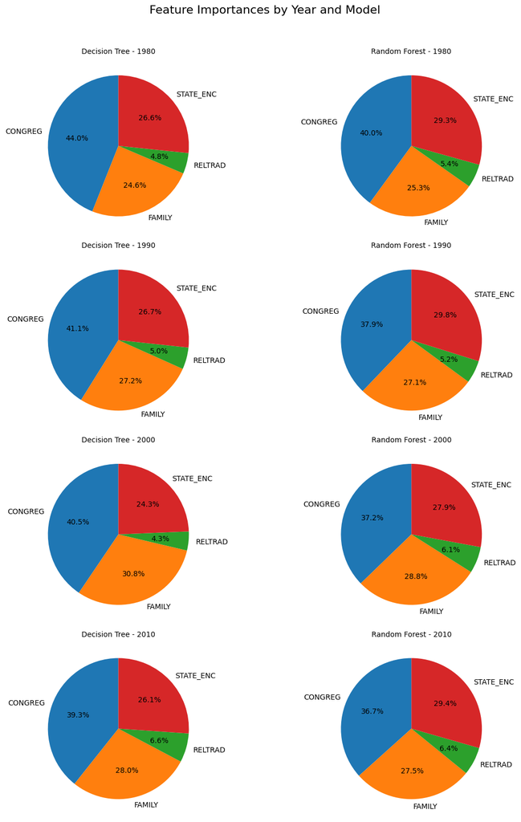

```python
import matplotlib.pyplot as plt

fig, axs = plt.subplots(4, 2, figsize=(12, 16))
fig.suptitle('Feature Importances by Year and Model', fontsize=16)

years_sorted = sorted(results.keys())
feature_names = ['CONGREG','FAMILY','RELTRAD','STATE_ENC']
model_keys = [('importances_DT', 'Decision Tree'), ('importances_RF', 'Random Forest')]

for i, year in enumerate(years_sorted):
    for j, (model_key, model_display_name) in enumerate(model_keys):
        ax = axs[i, j]
        importances = results[year][model_key]

        ax.pie(importances, labels=feature_names, autopct='%1.1f%%', startangle=90)
        ax.set_title(f'{model_display_name} - {year}', fontsize=10)

plt.tight_layout(rect=[0, 0, 1, 0.96])
plt.show()
```

Here we can see clearly that Congreg was the most important feature between both models over all years, and Reltrad was the least importnant. Family and State are comparable, however, so we can make a plot to see the difference.

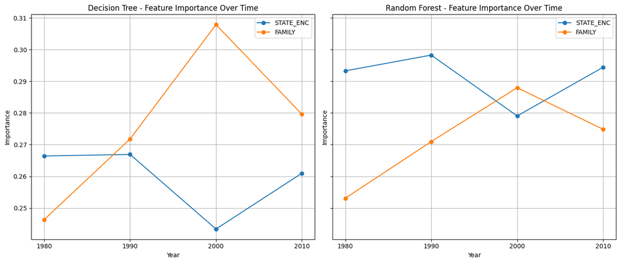

```python
import matplotlib.pyplot as plt
import pandas as pd

df_importances = pd.DataFrame(all_importances)

pivoted = df_importances.pivot_table(index='Year', columns=['Model', 'Feature'], values='Importance')

years = sorted(df_importances['Year'].unique())

fig, axs = plt.subplots(1, 2, figsize=(14, 6), sharey=True)
model_names = {'importances_DT': 'Decision Tree', 'importances_RF': 'Random Forest'}

for i, (model_key, model_title) in enumerate(model_names.items()):
    ax = axs[i]

    for feature in ['STATE_ENC', 'FAMILY']:
        ax.plot(
            years,
            pivoted[(model_key, feature)].values,
            label=feature,
            marker='o'
        )

    ax.set_title(f'{model_title} - Feature Importance Over Time')
    ax.set_xlabel('Year')
    ax.set_ylabel('Importance')
    ax.legend()
    ax.grid(True)

plt.tight_layout()
plt.show()
```

Some observations we can make about the data is the peak of the family feature in the year 2000 in both classification models. We can also notice that for both features, their change in importance over years is similar, even though their relative importance to each other is different. It is also interesting to note that Random Forest had a very slightly higher accuracy than Decision Tree, and it valued State generally higher than Decision tree.

# **7. Conclusion**

This project provided an examination of religious congregations across the United States. We used data from 1980 to 2010 to explore patterns in geography, adherence, and demographic factors. Through data preprocessing, hypothesis testing, machine learning analysis, and visualization, we have found that:

- The number of congregations in a county is the most significant predictor of high adherence rates
- Geographic regions have a statistically significant impact on affiliation with Hindu groups, with notable variations across the Midwestern and Western regions.
- The proportion of the population adhering to religious groups has not significantly changed over time, despite societal shifts.

Our Decision Tree and Random Forest classifiers demonstrated strong predictive abilities, with the congregation count consistently being the most important feature across all years, which is inline with intuition (more places of worship typically indicates more people attending the worships). To conclude, this project has given us a clearer understanding of religious adherence in the United States across different regions and times. Futher research could look to explore post-2010 data, including examining newer religious movements that were not reflected in our chosen dataset.